# Rapport d’étude statistique

## Problématique: Quels sont les principales causes du cout de chauffage dans une habitation?

Le cout de chauffage dans une habitation peut dependre de beaucoup de facteurs, la taille de l’habitation, l’isolation, l’année de construction, etc. Cependant, certainnes causes vont beaucoup plus influé sur la consomation.

Quelques chiffres qui nous aideront à mieux comprendre le probleme:

```
## [1] "Moyenne du cout de chauffage par habitation"
```

```
## [1] 1078.452
```

```
## [1] "Nombre d'habitation selon le type de batiment"
```

```
## appartement    immeuble      maison
##      217825        3844       27188
```

```
## [1] "Année pour laquelle le plus de logements ont été construit"
```

```
## [1] 1947
```

## Quelques graphiques

Un bon moyen de connaitre la performance energitique de votre habitation est de regarder son étiquette DPE.

Voici la répartition des étiquettes DPE pour les logements du Rhône.

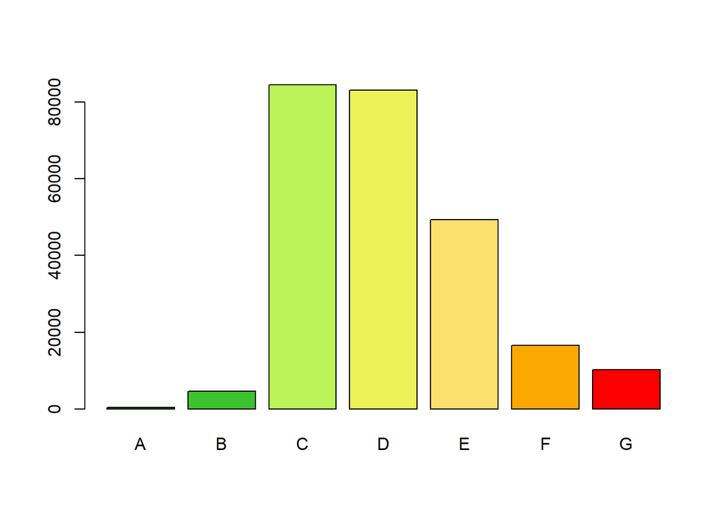

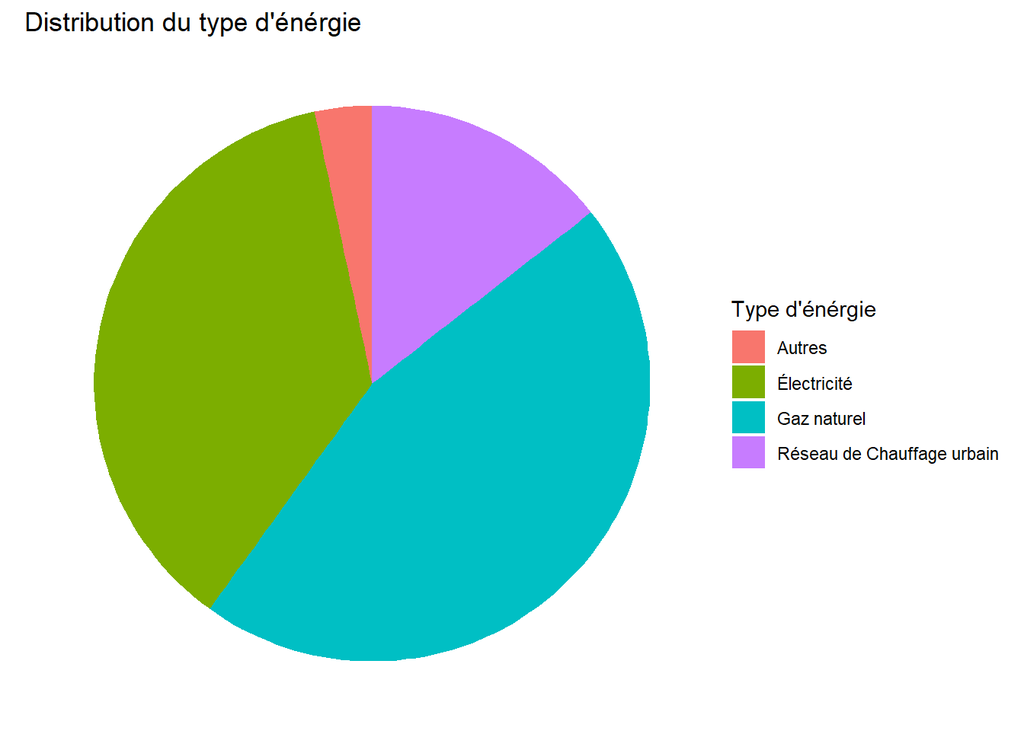

## Corelations

Pour trouver la cause la plus importante qui influe sur le coup de chauffage, le mieux est de regarder la correlation entre les differentes variables et de les comparés :

Correlation avec le type de batiment:

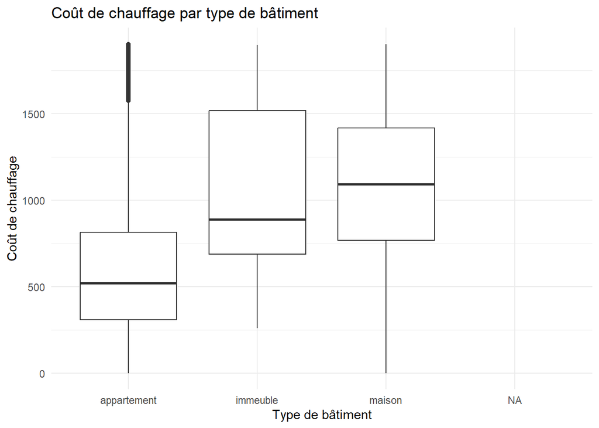

Correlation avec l’étiquette DPE:

[figure not shown]

Correlation avec l’emmission de Gaz à Effet de Serre (GES):

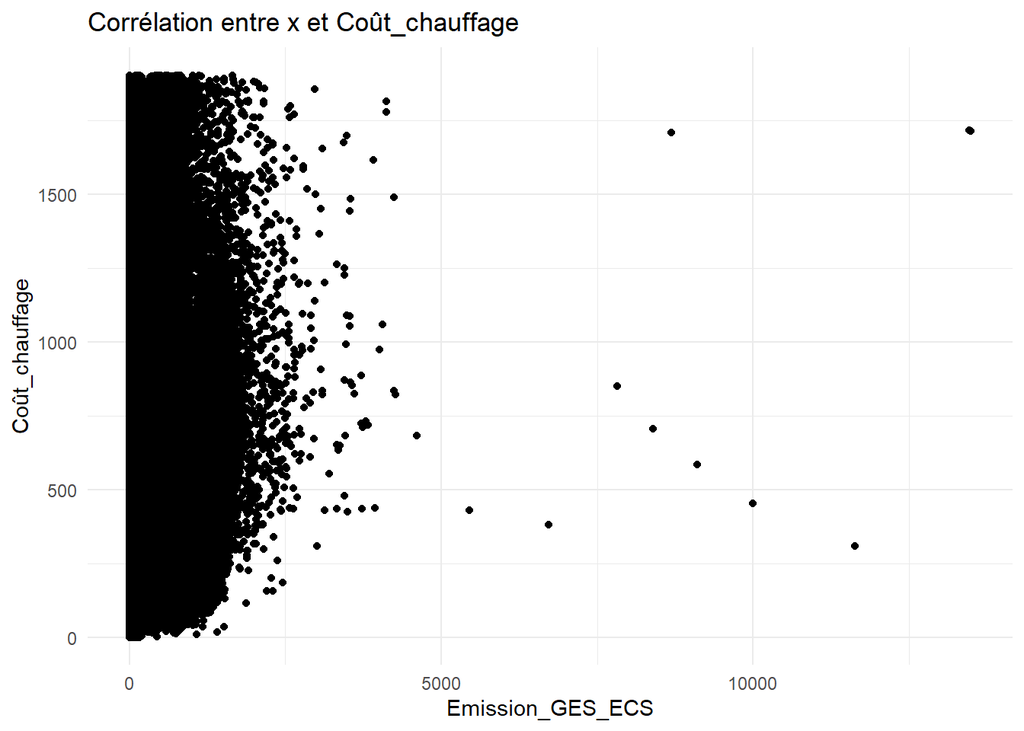

```
## [1] "indice de correlation:"
```

```
## [1] 0.05601051
```

## Conclusion

Il y a beaucoup de variables qui peuvent influer sur le coup de chauffage mais d’autres nom, avec une correlation de 0.05, on peut dire que l’emission de GES n’influe pas sur le cout de chauffage.

Pour le type de batiment et pour l’etiquette DPE, on voit que les boites a moustaches vont beaucoup change en fonction du type de batiment ou de l’etiquette, on peut donc en deduire une plutot forte corrélation avec le cout de chauffage.

Les principales causes de l’évolution du cout de chauffage dans une habitation sont le type de chauffage, la performance énérgitique, le type de batiment etc.